# Shared latent states in mvgam

Nicholas J Clark

2025-03-14

This vignette gives an example of how `mvgam` can be used to estimate models where multiple observed time series share the same latent process model. For full details on the basic `mvgam` functionality, please see [the introductory vignette](https://nicholasjclark.github.io/mvgam/articles/mvgam_overview.html).

## The `trend_map` argument

The `trend_map` argument in the `mvgam()` function is an optional `data.frame` that can be used to specify which series should depend on which latent process models (called “trends” in `mvgam`). This can be particularly useful if we wish to force multiple observed time series to depend on the same latent trend process, but with different observation processes. If this argument is supplied, a latent factor model is set up by setting `use_lv = TRUE` and using the supplied `trend_map` to set up the shared trends. Users familiar with the `MARSS` family of packages will recognize this as a way of specifying the $Z$ matrix. This `data.frame` needs to have column names `series` and `trend`, with integer values in the `trend` column to state which trend each series should depend on. The `series` column should have a single unique entry for each time series in the data, with names that perfectly match the factor levels of the `series` variable in `data`). For example, if we were to simulate a collection of three integer-valued time series (using `sim_mvgam`), the following `trend_map` would force the first two series to share the same latent trend process:

```r
set.seed(122)
simdat <- sim_mvgam(
  trend_model = AR(),
  prop_trend = 0.6,
  mu = c(0, 1, 2),
  family = poisson()
)
trend_map <- data.frame(
  series = unique(simdat$data_train$series),
  trend = c(1, 1, 2)
)
trend_map
```

```
#>     series trend
#> 1 series_1     1
#> 2 series_2     1
#> 3 series_3     2
```

We can see that the factor levels in `trend_map` match those in the data:

```r
all.equal(levels(trend_map$series),
          levels(simdat$data_train$series))
```

```
#> [1] TRUE
```

### Checking `trend_map` with `run_model = FALSE`

Supplying this `trend_map` to the `mvgam` function for a simple model, but setting `run_model = FALSE`, allows us to inspect the constructed `Stan` code and the data objects that would be used to condition the model. Here we will set up a model in which each series has a different observation process (with only a different intercept per series in this case), and the two latent dynamic process models evolve as independent AR1 processes that also contain a shared nonlinear smooth function to capture repeated seasonality. This model is not too complicated but it does show how we can learn shared and independent effects for collections of time series in the `mvgam` framework:

```r
fake_mod <- mvgam(
  y ~
    # observation model formula, which has a
    # different intercept per series
    series - 1,

  # process model formula, which has a shared seasonal smooth
  # (each latent process model shares the SAME smooth)
  trend_formula = ~ s(season, bs = "cc", k = 6),

  # AR1 dynamics (each latent process model has DIFFERENT)
  # dynamics; processes are estimated using the noncentred
  # parameterisation for improved efficiency
  trend_model = AR(),
  noncentred = TRUE,

  # supplied trend_map
  trend_map = trend_map,

  # data and observation family
  family = poisson(),
  data = simdat$data_train,
  run_model = FALSE
)
```

Inspecting the `Stan` code shows how this model is a dynamic factor model in which the loadings are constructed to reflect the supplied `trend_map`:

```r
stancode(fake_mod)
```

```
#> // Stan model code generated by package mvgam
#> data {
#>   int<lower=0> total_obs; // total number of observations
#>   int<lower=0> n; // number of timepoints per series
#>   int<lower=0> n_sp_trend; // number of trend smoothing parameters
#>   int<lower=0> n_lv; // number of dynamic factors
#>   int<lower=0> n_series; // number of series
#>   matrix[n_series, n_lv] Z; // matrix mapping series to latent states
#>   int<lower=0> num_basis; // total number of basis coefficients
#>   int<lower=0> num_basis_trend; // number of trend basis coefficients
#>   vector[num_basis_trend] zero_trend; // prior locations for trend basis coefficients
#>   matrix[total_obs, num_basis] X; // mgcv GAM design matrix
#>   matrix[n * n_lv, num_basis_trend] X_trend; // trend model design matrix
#>   array[n, n_series] int<lower=0> ytimes; // time-ordered matrix (which col in X belongs to each [time, series] observation?)
#>   array[n, n_lv] int ytimes_trend;
#>   int<lower=0> n_nonmissing; // number of nonmissing observations
#>   matrix[4, 4] S_trend1; // mgcv smooth penalty matrix S_trend1
#>   array[n_nonmissing] int<lower=0> flat_ys; // flattened nonmissing observations
#>   matrix[n_nonmissing, num_basis] flat_xs; // X values for nonmissing observations
#>   array[n_nonmissing] int<lower=0> obs_ind; // indices of nonmissing observations
#> }
#> transformed data {
#>
#> }
#> parameters {
#>   // raw basis coefficients
#>   vector[num_basis] b_raw;
#>   vector[num_basis_trend] b_raw_trend;
#>
#>   // latent state SD terms
#>   vector<lower=0>[n_lv] sigma;
#>
#>   // latent state AR1 terms
#>   vector<lower=-1, upper=1>[n_lv] ar1;
#>
#>   // raw latent states
#>   matrix[n, n_lv] LV_raw;
#>
#>   // smoothing parameters
#>   vector<lower=0>[n_sp_trend] lambda_trend;
```

[output cut: 74 more lines]

```
#>   matrix[n, n_series] mus;
#>   vector[n_sp_trend] rho_trend;
#>   vector[n_lv] penalty;
#>   array[n, n_series] int ypred;
#>   penalty = 1.0 / (sigma .* sigma);
#>   rho_trend = log(lambda_trend);
#>
#>   matrix[n_series, n_lv] lv_coefs = Z;
#>   // posterior predictions
#>   eta = X * b;
#>   for (s in 1 : n_series) {
#>     mus[1 : n, s] = eta[ytimes[1 : n, s]] + trend[1 : n, s];
#>     ypred[1 : n, s] = poisson_log_rng(mus[1 : n, s]);
#>   }
#> }
```

Notice the line that states “lv_coefs = Z;”. This uses the supplied $Z$ matrix to construct the loading coefficients. The supplied matrix now looks exactly like what you’d use if you were to create a similar model in the `MARSS` package:

```r
fake_mod$model_data$Z
```

```
#>      [,1] [,2]
#> [1,]    1    0
#> [2,]    1    0
#> [3,]    0    1
```

### Fitting and inspecting the model

Though this model doesn’t perfectly match the data-generating process (which allowed each series to have different underlying dynamics), we can still fit it to show what the resulting inferences look like:

```r
full_mod <- mvgam(
  y ~ series - 1,
  trend_formula = ~ s(season, bs = "cc", k = 6),
  trend_model = AR(),
  noncentred = TRUE,
  trend_map = trend_map,
  family = poisson(),
  data = simdat$data_train,
  silent = 2
)
```

The summary of this model is informative as it shows that only two latent process models have been estimated, even though we have three observed time series. The model converges well

```r
summary(full_mod)
```

```
#> GAM observation formula:
#> y ~ series - 1
#> <environment: 0x00000204e4758610>
#>
#> GAM process formula:
#> ~s(season, bs = "cc", k = 6)
#> <environment: 0x00000204e4758610>
#>
#> Family:
#> poisson
#>
#> Link function:
#> log
#>
#> Trend model:
#> AR()
#>
#>
#> N process models:
#> 2
#>
#> N series:
#> 3
#>
#> N timepoints:
#> 75
#>
#> Status:
#> Fitted using Stan
#> 4 chains, each with iter = 1000; warmup = 500; thin = 1
#> Total post-warmup draws = 2000
#>
#>
#> GAM observation model coefficient (beta) estimates:
#>                 2.5%   50% 97.5% Rhat n_eff
#> seriesseries_1 -2.70 -0.75   1.3    1   581
#> seriesseries_2 -1.70  0.20   2.3    1   587
#> seriesseries_3 -0.81  1.20   3.3    1   579
#>
#> Process model AR parameter estimates:
```

[output cut: 19 more lines]

```
#> s(season) 2.71      4   18.4 9.6e-05 ***
#> ---
#> Signif. codes:  0 '***' 0.001 '**' 0.01 '*' 0.05 '.' 0.1 ' ' 1
#>
#> Stan MCMC diagnostics:
#> ✔ No issues with effective samples per iteration
#> ✔ Rhat looks good for all parameters
#> ✔ No issues with divergences
#> ✔ No issues with maximum tree depth
#>
#> Samples were drawn using sampling(hmc). For each parameter, n_eff is a
#>   crude measure of effective sample size, and Rhat is the potential scale
#>   reduction factor on split MCMC chains (at convergence, Rhat = 1)
#>
#> Use how_to_cite() to get started describing this model
```

Both series 1 and 2 share the exact same latent process estimates, while the estimates for series 3 are different:

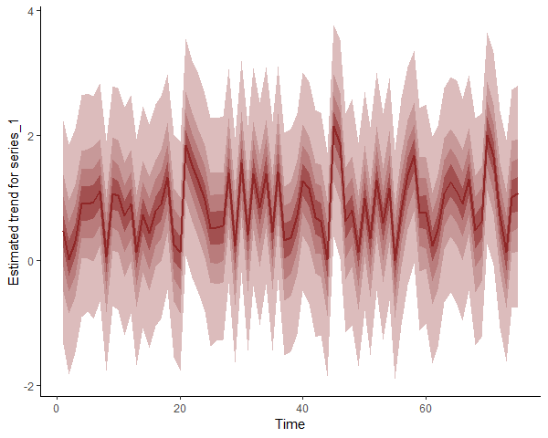

```r
plot(full_mod, type = "trend", series = 1)
```

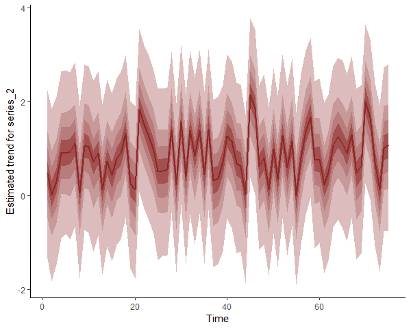

```r
plot(full_mod, type = "trend", series = 2)
```

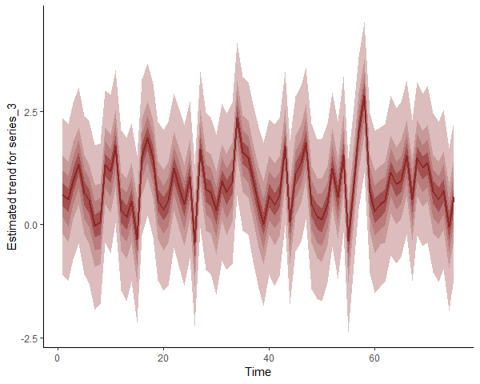

```r
plot(full_mod, type = "trend", series = 3)
```

However, forecasts for series’ 1 and 2 will differ because they have different intercepts in the observation model

## Example: signal detection

Now we will explore a more complicated example. Here we simulate a true hidden signal that we are trying to track. This signal depends nonlinearly on some covariate (called `productivity`, which represents a measure of how productive the landscape is). The signal also demonstrates a fairly large amount of temporal autocorrelation:

```r
set.seed(123)
# simulate a nonlinear relationship using the mgcv function gamSim
signal_dat <- mgcv::gamSim(n = 100, eg = 1, scale = 1)
```

```
#> Gu & Wahba 4 term additive model
```

```r
# productivity is one of the variables in the simulated data
productivity <- signal_dat$x2

# simulate the true signal, which already has a nonlinear relationship
# with productivity; we will add in a fairly strong AR1 process to
# contribute to the signal
true_signal <- as.vector(scale(signal_dat$y) +
  arima.sim(100, model = list(ar = 0.8, sd = 0.1)))
```

Plot the signal to inspect it’s evolution over time

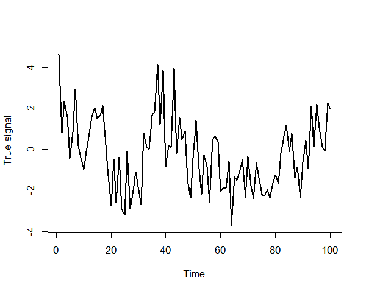

```r
plot(
  true_signal,
  type = "l",
  bty = "l", lwd = 2,
  ylab = "True signal",
  xlab = "Time"
)
```

Next we simulate three sensors that are trying to track the same hidden signal. All of these sensors have different observation errors that can depend nonlinearly on a second external covariate, called `temperature` in this example. Again this makes use of `gamSim`

```r
# Function to simulate a monotonic response to a covariate
sim_monotonic <- function(x, a = 2.2, b = 2) {
  out <- exp(a * x) / (6 + exp(b * x)) * -1
  return(2.5 * as.vector(scale(out)))
}

# Simulated temperature covariate
temperature <- runif(100, -2, 2)

# Simulate the three series
sim_series <- function(n_series = 3, true_signal) {
  temp_effects <- mgcv::gamSim(n = 100, eg = 7, scale = 0.05)
  alphas <- rnorm(n_series, sd = 2)

  do.call(rbind, lapply(seq_len(n_series), function(series) {
    data.frame(
      observed = rnorm(length(true_signal),
        mean = alphas[series] +
          sim_monotonic(temperature,
                            runif(1, 2.2, 3),
                            runif(1, 2.2, 3)) +
          true_signal,
        sd = runif(1, 1, 2)
      ),
      series = paste0("sensor_", series),
      time = 1:length(true_signal),
      temperature = temperature,
      productivity = productivity,
      true_signal = true_signal
    )
  }))
}
model_dat <- sim_series(true_signal = true_signal) %>%
  dplyr::mutate(series = factor(series))
```

```
#> Gu & Wahba 4 term additive model, correlated predictors
```

Plot the sensor observations

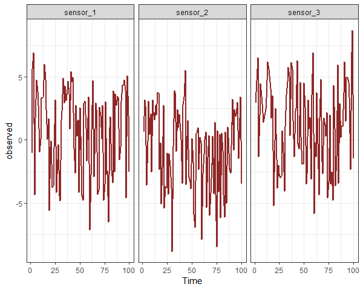

```r
plot_mvgam_series(
  data = model_dat, y = "observed",
  series = "all"
)
```

And now plot the observed relationships between the three sensors and the `temperature` covariate

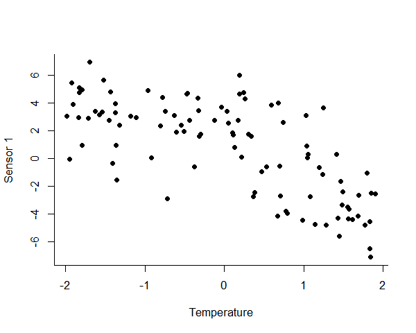

```r
plot(
  observed ~ temperature,
  data = model_dat %>%
    dplyr::filter(series == "sensor_1"),
  pch = 16, bty = "l",
  ylab = "Sensor 1",
  xlab = "Temperature"
)
```

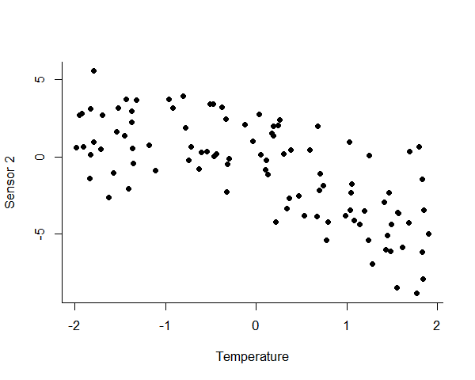

```r
plot(
  observed ~ temperature,
  data = model_dat %>%
    dplyr::filter(series == "sensor_2"),
  pch = 16, bty = "l",
  ylab = "Sensor 2",
  xlab = "Temperature"
)
```

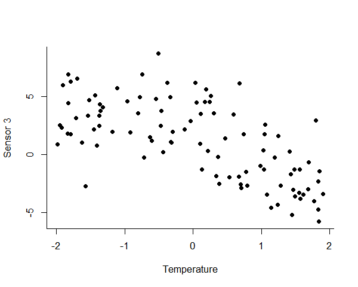

```r
plot(
  observed ~ temperature,
  data = model_dat %>%
    dplyr::filter(series == "sensor_3"),
  pch = 16, bty = "l",
  ylab = "Sensor 3",
  xlab = "Temperature"
)
```

### The shared signal model

Now we can formulate and fit a model that allows each sensor’s observation error to depend nonlinearly on `temperature` while allowing the true signal to depend nonlinearly on `productivity`. By fixing all of the values in the `trend` column to `1` in the `trend_map`, we are assuming that all observation sensors are tracking the same latent signal. We use informative priors on the two variance components (process error and observation error), which reflect our prior belief that the observation error is smaller overall than the true process error

```r
mod <- mvgam(
  formula =
  # formula for observations, allowing for different
  # intercepts and hierarchical smooth effects of temperature
    observed ~ series +
      s(temperature, k = 10) +
      s(series, temperature, bs = "sz", k = 8),
  trend_formula =
  # formula for the latent signal, which can depend
  # nonlinearly on productivity
    ~ s(productivity, k = 8) - 1,
  trend_model =
  # in addition to productivity effects, the signal is
  # assumed to exhibit temporal autocorrelation
    AR(),
  noncentred = TRUE,
  trend_map =
  # trend_map forces all sensors to track the same
  # latent signal
    data.frame(
      series = unique(model_dat$series),
      trend = c(1, 1, 1)
    ),

  # informative priors on process error
  # and observation error will help with convergence
  priors = c(
    prior(normal(2, 0.5), class = sigma),
    prior(normal(1, 0.5), class = sigma_obs)
  ),

  # Gaussian observations
  family = gaussian(),
  data = model_dat,
  silent = 2
)
```

View a reduced version of the model summary because there will be many spline coefficients in this model

```r
summary(mod, include_betas = FALSE)
```

```
#> GAM observation formula:
#> observed ~ series + s(temperature, k = 10) + s(series, temperature,
#>     bs = "sz", k = 8)
#> <environment: 0x00000204e4758610>
#>
#> GAM process formula:
#> ~s(productivity, k = 8) - 1
#> <environment: 0x00000204e4758610>
#>
#> Family:
#> gaussian
#>
#> Link function:
#> identity
#>
#> Trend model:
#> AR()
#>
#>
#> N process models:
#> 1
#>
#> N series:
#> 3
#>
#> N timepoints:
#> 100
#>
#> Status:
#> Fitted using Stan
#> 4 chains, each with iter = 1100; warmup = 600; thin = 1
#> Total post-warmup draws = 2000
#>
#>
#> Observation error parameter estimates:
#>              2.5% 50% 97.5% Rhat n_eff
#> sigma_obs[1]  1.3 1.5   1.8    1  2434
#> sigma_obs[2]  1.2 1.4   1.6    1  2264
#> sigma_obs[3]  1.2 1.5   1.7    1  2400
#>
```

[output cut: 23 more lines]

```
#> s(productivity) 2.33      7   35.7   0.029 *
#> ---
#> Signif. codes:  0 '***' 0.001 '**' 0.01 '*' 0.05 '.' 0.1 ' ' 1
#>
#> Stan MCMC diagnostics:
#> ✔ No issues with effective samples per iteration
#> ✔ Rhat looks good for all parameters
#> ✔ No issues with divergences
#> ✔ No issues with maximum tree depth
#>
#> Samples were drawn using sampling(hmc). For each parameter, n_eff is a
#>   crude measure of effective sample size, and Rhat is the potential scale
#>   reduction factor on split MCMC chains (at convergence, Rhat = 1)
#>
#> Use how_to_cite() to get started describing this model
```

### Inspecting effects on both process and observation models

Don’t pay much attention to the approximate *p*-values of the smooth terms. The calculation for these values is incredibly sensitive to the estimates for the smoothing parameters so I don’t tend to find them to be very meaningful. What are meaningful, however, are prediction-based plots of the smooth functions. All main effects can be quickly plotted with `conditional_effects`:

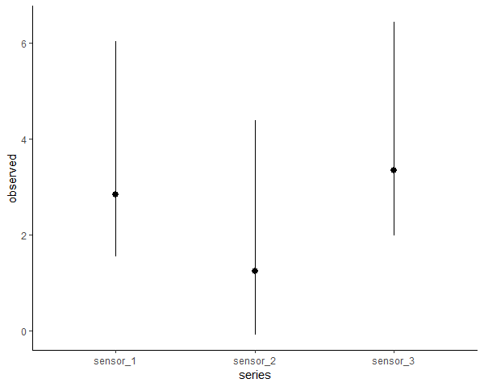

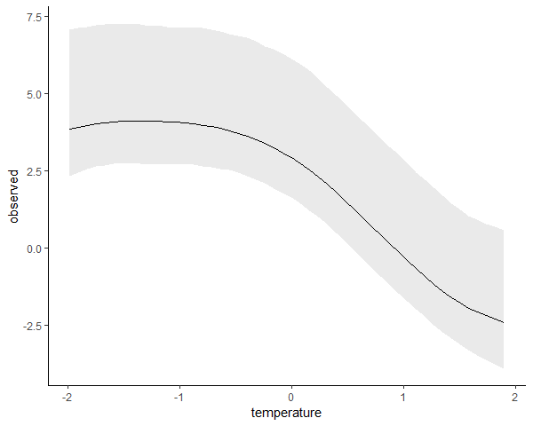

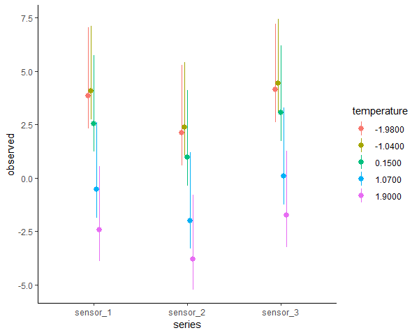

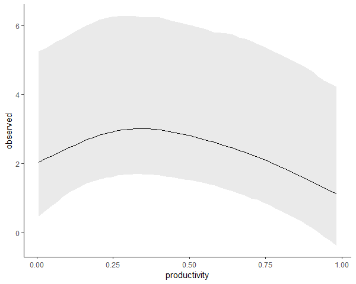

```r
conditional_effects(mod, type = "link")
```

`conditional_effects` is simply a wrapper to the more flexible `plot_predictions` function from the `marginaleffects` package. We can get more useful plots of these effects using this function for further customisation:

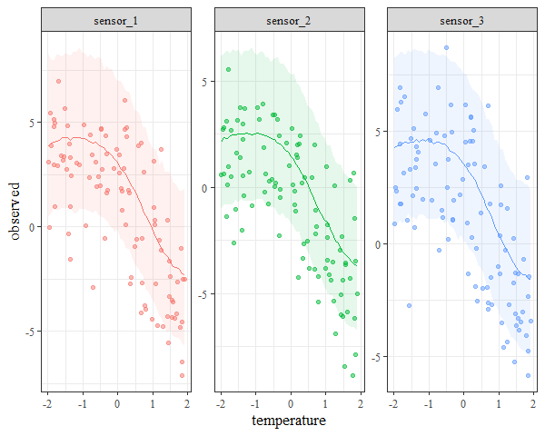

```r
plot_predictions(
  mod,
  condition = c("temperature", "series", "series"),
  points = 0.5
) +
  theme(legend.position = "none")
```

We have successfully estimated effects, some of them nonlinear, that impact the hidden process AND the observations. All in a single joint model. But there can always be challenges with these models, particularly when estimating both process and observation error at the same time.

### Recovering the hidden signal

A final but very key question is whether we can successfully recover the true hidden signal. The `trend` slot in the returned model parameters has the estimates for this signal, which we can easily plot using the `mvgam` S3 method for `plot`. We can also overlay the true values for the hidden signal, which shows that our model has done a good job of recovering it:

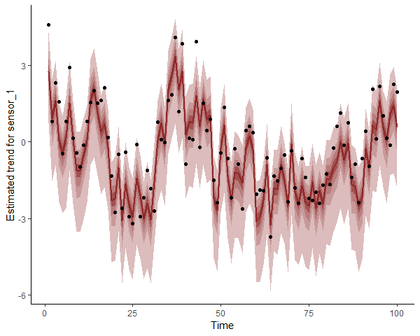

```r
plot(mod,
     type = "trend") +
  ggplot2::geom_point(data = data.frame(time = 1:100,
                                        y = true_signal),
                      mapping = ggplot2::aes(x = time,
                                             y = y))
```

## Further reading

The following papers and resources offer a lot of useful material about other types of State-Space models and how they can be applied in practice:

Auger‐Méthé, Marie, et al. [“A guide to state–space modeling of ecological time series.](https://esajournals.onlinelibrary.wiley.com/doi/full/10.1002/ecm.1470)” *Ecological Monographs* 91.4 (2021): e01470.

Clark, Nicholas J., et al. [Beyond single-species models: leveraging multispecies forecasts to navigate the dynamics of ecological predictability](https://peerj.com/articles/18929/). *PeerJ*. (2025): 13:e18929

Holmes, Elizabeth E., Eric J. Ward, and Wills Kellie. “[MARSS: multivariate autoregressive state-space models for analyzing time-series data.](https://journal.r-project.org/archive/2012/RJ-2012-002/index.html)” *R Journal*. 4.1 (2012): 11.

Ward, Eric J., et al. “[Inferring spatial structure from time‐series data: using multivariate state‐space models to detect metapopulation structure of California sea lions in the Gulf of California, Mexico.](https://besjournals.onlinelibrary.wiley.com/doi/full/10.1111/j.1365-2664.2009.01745.x)” *Journal of Applied Ecology* 47.1 (2010): 47-56.

## Interested in contributing?

I’m actively seeking PhD students and other researchers to work in the areas of ecological forecasting, multivariate model evaluation and development of `mvgam`. Please reach out if you are interested (n.clark’at’uq.edu.au)